# ACE Parental linkage

# Identifying parents from commissioning data sets

ACE is based on parental exposures, therefore need way to identify if the children are living with parents and who their parents are. Especially to look at parental separation. The only parental link directly recorded in commissioning data sets is between mother and their baby. At birth registration the Mother’s and Father’s Date of Births are recorded. Could this be sufficient to link to who a child is living with today.

Got this for all under 13 year olds, as we have births from 2013. Off course children will move in and out of the area. The cohort here is children living in the ICB, we will not know the parentage for those born outside and moved in. This restricts our cohort to just those born and currently living in the ICB.

## Do children live with birth parents?

Starting point is the Birth where the mother and father’s DOB is recorded along with the baby’s NHS Number.

Starting point is the Birth where the mother and father’s DOB is recorded along with the baby’s NHS Number.

### How many births have there been since when.

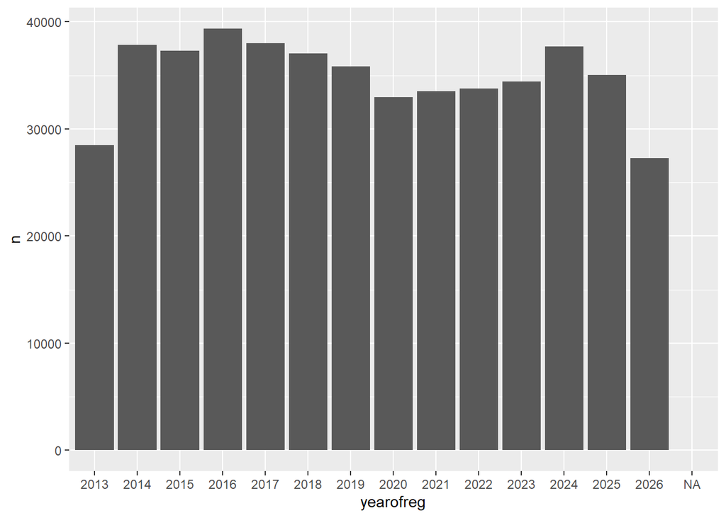

## Population linkage

There are two data sets for current residents:

1. NHS Spine extract for resident population
2. NHS Spine linked to UPRN

For some reason there are more in the UPRN than the Spine extract, despite NHS number appearing only once in each data sets.

As the Spine extract is regarded as the TRUTH then only those UPRN records with a match to a child in the resident file are going to be used

Some babies will be born in ICB but not live there, and some will move out of the ICB, these births need to be excluded.

Join the households in which the babies born in ICB live CURRENTLY based on the birth NHS number and MPI NHS number.

The births only go back to 2013 so any child aged over 13 will not have a birth record.

Anti join births to all children to exclude those not in born in ICB and any over age 13 for whom we do not know the Mother and Father’s DOB.

Find the adults in those households by joining all the NHS numbers in those households aged over 18. This is the target list of parents in households for children born and living in BBCS aged <13

Looking for the babies household and then testing whether the mother or fathers dob match to any adult in household

### How many children are living with their mother aged under 13 born and living in BBCS?

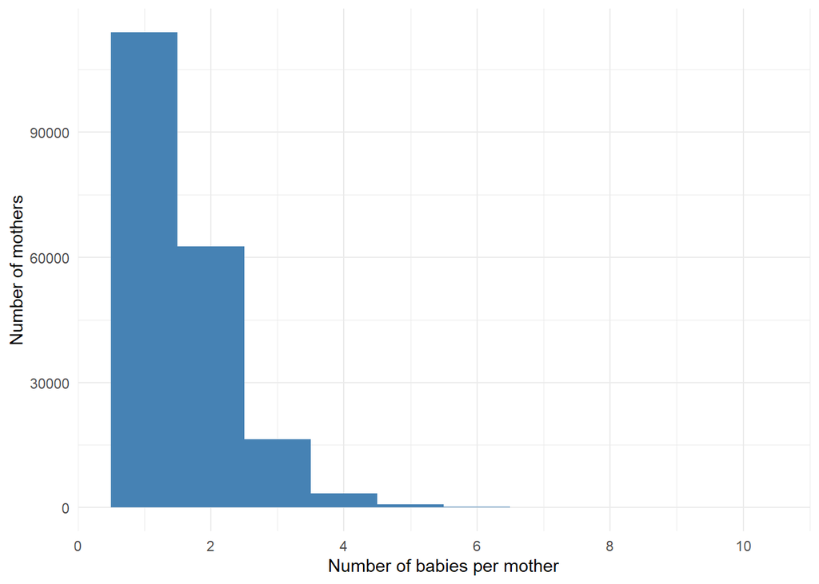

| n_babies | Babies_per_mother |
| --- | --- |
| 1 | 113875 |
| 2 | 62565 |
| 3 | 16325 |
| 4 | 3455 |
| 5 | 750 |
| 6 | 155 |
| 7 | 50 |
| 8 | 10 |
| 9 | 10 |
| 10 | 10 |

### How many children are living with their father aged under 13 born and living in BBCS?

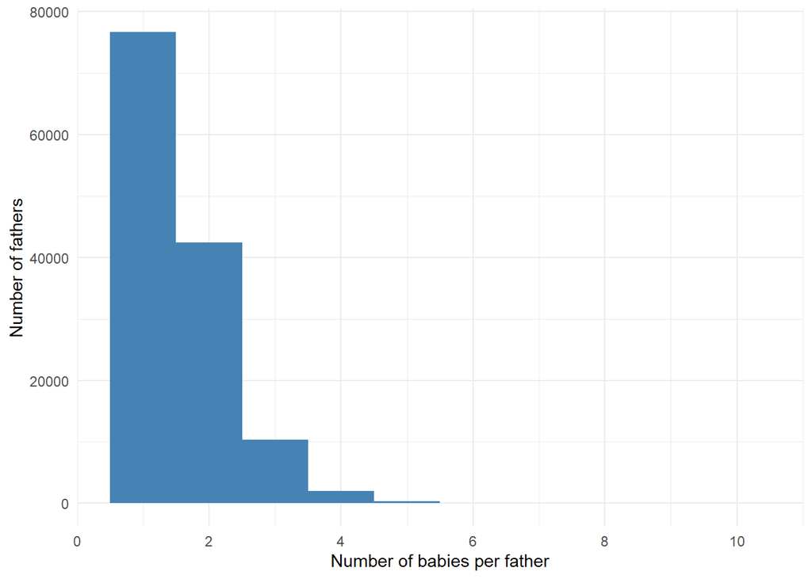

| n_babies | Babies_per_father |
| --- | --- |
| 1 | 76675 |
| 2 | 42470 |
| 3 | 10325 |
| 4 | 1970 |
| 5 | 375 |
| 6 | 70 |
| 7 | 25 |
| 8 | 10 |
| 10 | 10 |

## Check back vs MSDS for mother’s NHS Number

### Does birth HHS + Mothers NHS match MSDS NHS numbers

| matches | deliveries | mismatch | Matchpct | MisMatchpct |
| --- | --- | --- | --- | --- |
| 71885 | 72150 | 265 | 99.6 | 0.4 |

## Summary

There are:

342407 children under age 13 born in BBCS, still living in BBCS

306602 (89.5 %) are living with their birth mother

202913 (59.3 %) are living with their birth Father

## Parents list for ACE cohort

There are duplicates records caused by loose joins which should be removed.

### Who are not living with Birth parent

| Parents | n | pct |
| --- | --- | --- |
| Not WIth Mother | 12968 | 3.8 |
| Neither | 22997 | 6.7 |
| Not WIth Father | 116885 | 34.1 |

There are few statistics to compare the data to. The closet can get is from the Census, which shows that 24% of children were in single parent households in Birmingham, but we do not know how many of the married and cohabiting couples are birth parents.

Link to Census data.

https://www.ons.gov.uk/datasets/create/filter-outputs/2cb5fae5-ed37-4e57-b784-fbcf136240e5#get-data

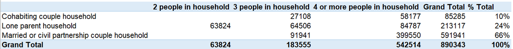

## Where do the children not identified as living with birth parent live?

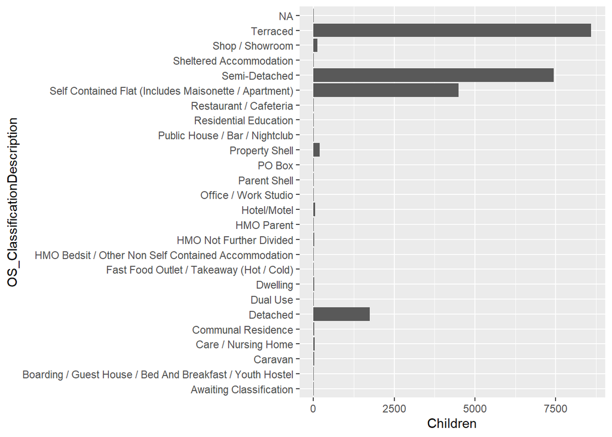

### Age and gender

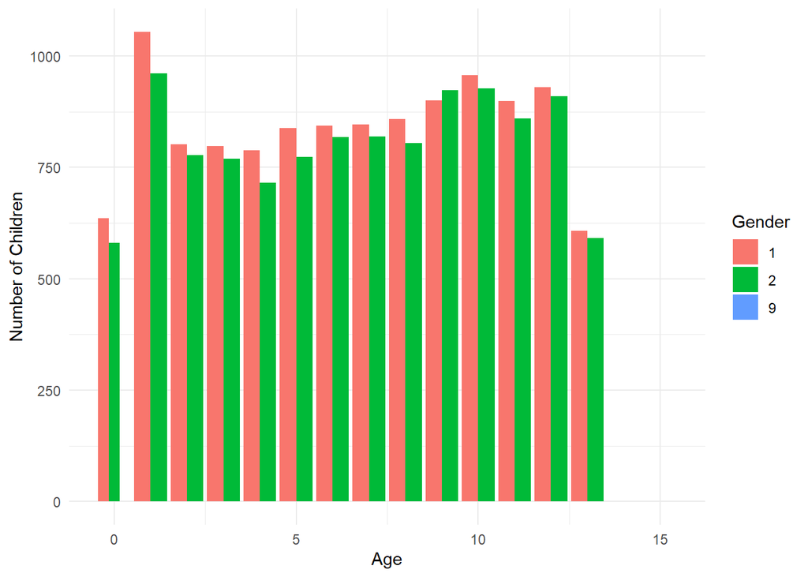

### Ethnicity_Full_Description

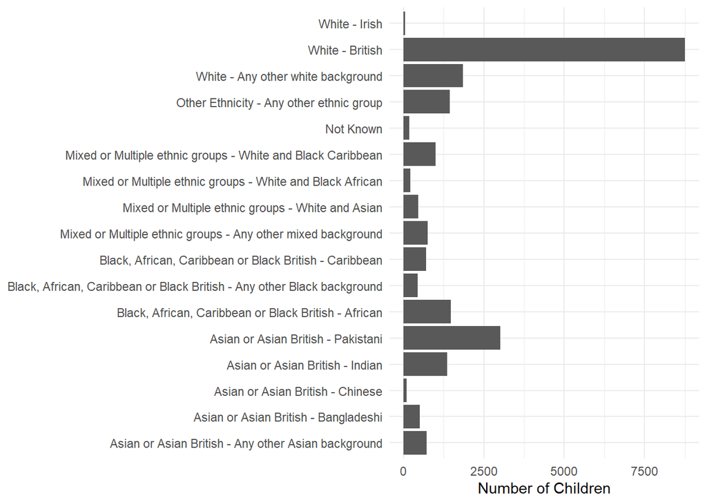

### PrimaryCareProviderEffectiveDate

Have they moved recently?

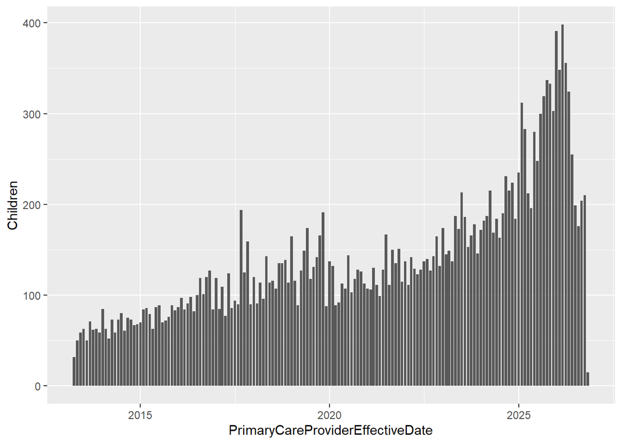